# Tarea_1

## Curso de introducción a la programación con Python

**Autor: Luis Fernando Apáez Álvarez**  
-Curso PyM-  
Tarea 1: Ecuación lineal  
Fecha de Entrega: 09 de Agosto del 2022

**Descripción:** En esta tarea crearemos un programa para resolver ecuaciones lineales. Asimismo, veremos un poco de teoría adicional que nos permitirá graficar la función lineal asociada a dicha ecuación y ver, además, gráficamente el punto sólución de ésta. (Tiempo estimado: **30 minutos**)

**Teoría:** Una ecuación lineal es de la forma $ax+b=0$, donde $a\neq 0$. Podemos resolver dicha ecuación como sigue:

- $ax = -b$: Pasamos la $b$ restando del otro lado de la ecuación
- $x = -\frac{b}{a}$: Dado que $a\neq 0$, podemos pasar este valor del otro lado de la ecuación dividiendo.

De tal manera, para resolver una ecuación lineal de manera general, basta con conocer los valores de $a$ y $b$. Nota que el resultado anterior puede considerarse como una especie de "chicharronera" para ecuaciones de grado 1:

$$ x = -\frac{b}{a}, \ \ a\neq 0 $$

¿Existe alguna fórmula como la "chicharronera" para resolver ecuaciones de grado 3, 4 ó 5? Tal vez pueda interesarte:

[Por qué no hay solución general de la ecuación de quinto grado](https://www.gaussianos.com/por-que-no-hay-solucion-general-de-la-ecuacion-de-quinto-grado/)

### Instrucciones

Bien, ahora implementaremos el análisis anterior para crear el código de nuestro programa, para lo cual:

(1) Daremos un mensaje al usuario especificando que la ecuación lineal que quiere resolver debe ser de la forma $ax+b=0$, es decir, su ecuación debe estar igualada a cero. También, le pediremos que ingrese los valores de $a$ y $b$:

```python
# Mensaje de bienvenida
print("Bienvenido, este programa resuelve ecuaciones de primer grado")
print("-" * 50)

# Le especificamos sobre la forma de la ecuacion
print("Tu ecuación lineal debe ser de la forma ax+b=0")
print("-" * 50)

# Le pedimos que ingrese los valores de a y de b
# (Sustituye _ _ _ por el codigo que debe ir para que el usuario ingrese
# la informacion que le pedimos, ten cuidado con los tipos de datos)
print("Ingrese el valor de a (no debe ser cero): ")
a = _ _ _

print("Ingrese el valor de b: ")
b = _ _ _
```

(2) como vimos en la parte de teoría, la solución a cualquier ecuación lineal es $x=-\frac{b}{a}$. Tu labor es definir de manera correcta la variable `x0` de abajo

```python
# Define la variable x que almacene la solucion de la
# ecuacion lineal que ingrese el usuario.
# El nombre que le daremos a la variable x sera x0
x0 = _ _ _
```

(3) Una vez hecho todo lo anterior, mostraremos un mensaje final al usuario mostrándole el valor solución de `x0` correspondiente a su ecuación:

```python
# Escribe el mensaje final que le mostraremos al usuario
# como se indico antes. Para ello utiliza un f string
# (Recuerda que para utilizar valores de varibles dentro de
# tu f string debes usar {})

msj_final = _ _ _

# Mostraremos ahora
_ _ _ (msj_final)
```

### Adicional

Ahora, escribiremos el código necesario para mostrar la gráfica de la función lineal asociada a la ecuación lineal dada. Por ejemplo, para la ecuación lineal $ax+b=0$, la función lineal asociada es $f(x)=ax+b$, donde la solución de $ax+b=0$ representa la coordenada $x$ del punto de intersección entre $f(x)$ y el eje $x$. Por ejemplo, si tenemos la ecuación $2x+1=0$, podemos considerar la función lineal $f(x)=2x+1$, así como el punto solución $(-0.5,0)$, donde en este caso $x_{0}=-0.5$:

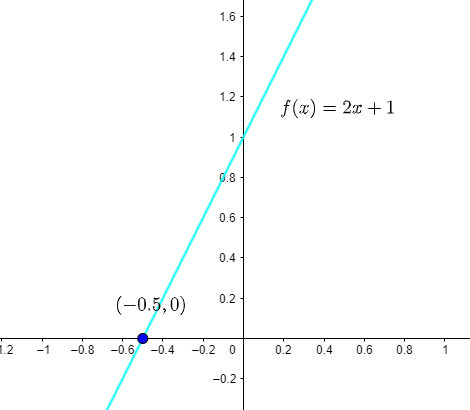

Ahora bien, lo que haremos será mostrar al usuario una gráfica como la anterior para la ecuación lineal que ingresó. Para ello:

(1) Realizaremos la importación de dos paquetes (los paquetes traen nuevas funcionalidades que podemos utilizar). El primer paquete nos permite realizar gráficos en **Python** y el segundo nos permite crear rangos de números (por ejemplo el rango de números que va del -5 al 5 para simular el intervalo $(-5,5)$)

(*Ahorita no le prestes tanta atención a lo que estamos haciendo, tampoco te preocupes sino le estás entendiendo a esta parte, más adelante veremos a profundidad esto*)

```python
# Importaciones necesarias:
# Paquete 1:
# nos permite realizar gráficos en Python
import matplotlib.pyplot as plt

# Paquete 2:
# nos permite crear rangos de números
import numpy as np
```

(2) Ahora, graficaremos la función lineal asociada a la ecuación que ingresó el usuario. Para ello, primero crearemos el rango de graficación utilizando la función `np.arange()`. Así, como queremos crear el intervalo $(-5,5)$, escribiremos entonces `np.arange(-5,5)`. Luego definimos la función lineal a graficar, la cual almacenaremos en una variable denominada `y`, de tal manera `y = a * x + b`. Finalmente creamos el gráfico con la función `plt.plot()` cuyo parámetro es la función que queremos graficar, por lo cual escribiremos `plt.plot(x,y)`

```python
# Creamos el rango de graficacion del -5 al 5
x = np.arange(-5,5)

# defimos la funcion lineal
y = a * x + b

# graficamos la funcion anterior
plt.plot(x, y)

# graficamos tambien el punto de interseccion con el eje x
plt.plot(x0, 0, marker="o")

# mostramos una cuadricula
plt.grid()

# mostramos el grafico
plt.show()
```

Por ejemplo, si el usuario ingresó el valor de 2 para $a$ y el valor de 1 para $b$, entonces el código que escribimos antes deberá mostrar:

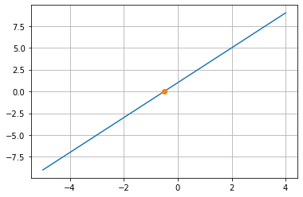

```python
a = 2
b = 1
x0 = -b / a
# -------------------
# -------------------
# -------------------

# Creamos el rango de graficacion del -5 al 5
x = np.arange(-5,5)

# defimos la funcion lineal
y = a * x + b

# graficamos la funcion anterior
plt.plot(x, y)

# graficamos tambien el punto de interseccion con el eje x
plt.plot(x0, 0, marker="o")

# mostramos una cuadricula
plt.grid()

# mostramos el grafico
plt.show()
```

[figure not shown]